# CEMA_Magdalene_Mbiti_Monthe

Magdalene Monthe Mbiti

7/21/2023

Upload the data into R

```r
CEMA.Dataset <- read.csv("~/CEMA Dataset.csv", quote="", stringsAsFactors=TRUE)
View(CEMA.Dataset)
```

Conducting some exploratory analysis

1. Summary statistics

```r
head(CEMA.Dataset)
```

|  | period | county | Total.Dewormed | Acute.Malnutrition | stunted.6.23.months | stunted.0..6.months | stunted.24.59.months | diarrhoea.cases | Underweight.0..6.months | Underweight.6.23.months | Underweight.24.59.Months |
| --- | --- | --- | --- | --- | --- | --- | --- | --- | --- | --- | --- |
| 1 | 23-Jan | Baringo County | 3659 | 8 | 471 | 34 | 380 | 2620 | 85 | 739 | 731 |
| 2 | 23-Jan | Bomet County | 1580 | NA | 1 | 3 | NA | 1984 | 41 | 86 | 16 |
| 3 | 23-Jan | Bungoma County | 6590 | 24 | 98 | 154 | 23 | 4576 | 231 | 315 | 120 |
| 4 | 23-Jan | Busia County | 7564 | NA | 396 | 143 | 111 | 2239 | 251 | 608 | 125 |
| 5 | 23-Jan | Elgeyo Marakwet County | 1407 | NA | 92 | 71 | 5 | 2739 | 57 | 104 | 21 |
| 6 | 23-Jan | Embu County | 3241 | 72 | 326 | 86 | 24 | 1376 | 141 | 544 | 160 |

```r
summary(CEMA.Dataset)
```

```
##      period                        county     Total.Dewormed
##  21-Apr :  47   West Pokot County     :  31   Min.   :    97
##  21-Aug :  47   Baringo County        :  30   1st Qu.:  2456
##  21-Dec :  47   Bomet County          :  30   Median :  4568
##  21-Feb :  47   Bungoma County        :  30   Mean   : 11455
##  21-Jan :  47   Busia County          :  30   3rd Qu.:  8215
##  21-Jul :  47   Elgeyo Marakwet County:  30   Max.   :392800
##  (Other):1130   (Other)               :1231   NA's   :1
##  Acute.Malnutrition stunted.6.23.months stunted.0..6.months
##  Min.   :   1.0     Min.   :   1.0      Min.   :   1.00
##  1st Qu.:  15.0     1st Qu.:  69.0      1st Qu.:  36.75
##  Median :  38.5     Median : 159.0      Median :  84.00
##  Mean   : 125.3     Mean   : 280.0      Mean   : 139.73
##  3rd Qu.: 143.2     3rd Qu.: 328.2      3rd Qu.: 157.00
##  Max.   :4123.0     Max.   :4398.0      Max.   :7900.00
##  NA's   :356        NA's   :12          NA's   :20
##  stunted.24.59.months diarrhoea.cases Underweight.0..6.months
##  Min.   :   1.0       Min.   :  198   Min.   :   6.0
##  1st Qu.:  22.0       1st Qu.: 1464   1st Qu.:  87.0
##  Median :  50.0       Median : 2158   Median : 162.0
##  Mean   : 110.7       Mean   : 2813   Mean   : 223.3
##  3rd Qu.: 114.0       3rd Qu.: 3334   3rd Qu.: 272.5
##  Max.   :3169.0       Max.   :15795   Max.   :1937.0
##  NA's   :15           NA's   :1       NA's   :1
##  Underweight.6.23.months Underweight.24.59.Months
##  Min.   :  16.0          37     :  13
##  1st Qu.: 249.0          47     :  12
##  Median : 456.0          51     :  12
##  Mean   : 651.9          18     :  11
##  3rd Qu.: 791.5          50     :  11
##  Max.   :5348.0          57     :  11
##  NA's   :1               (Other):1342
```

Next is to check if the data has any missing values

```r
missing_values <- any(is.na(CEMA.Dataset))
print(missing_values)
```

```
## [1] TRUE
```

Given the the output its true, next is to check which columns have missing values

```r
missing_values_in_columns <- colSums(is.na(CEMA.Dataset))
print(missing_values_in_columns)
```

```
##                   period                   county           Total.Dewormed
##                        0                        0                        1
##       Acute.Malnutrition      stunted.6.23.months      stunted.0..6.months
##                      356                       12                       20
##     stunted.24.59.months          diarrhoea.cases  Underweight.0..6.months
##                       15                        1                        1
##  Underweight.6.23.months Underweight.24.59.Months
##                        1                        0
```

To check the number of complete data points that have no missing values

```r
complete_data_points <- sum(complete.cases(CEMA.Dataset))
print(complete_data_points)
```

```
## [1] 1049
```

To omit rows that have incomplete data sets

```r
CEMA.Dataset1<-na.omit(CEMA.Dataset)
print(CEMA.Dataset1)
```

[output not shown]

[output cut: 4185 more lines]

Now the dataset has no missing values making our new data frame CEMA.Dataset1

To work with only one column of stunted children below the age of 5

```r
CEMA.Dataset1$Stunted_children <- CEMA.Dataset1$stunted.6.23.months + CEMA.Dataset1$stunted.0..6.months + CEMA.Dataset1$stunted.24.59.months
print(CEMA.Dataset1)
```

[output not shown]

[output cut: 4185 more lines]

To check the distribution of the data

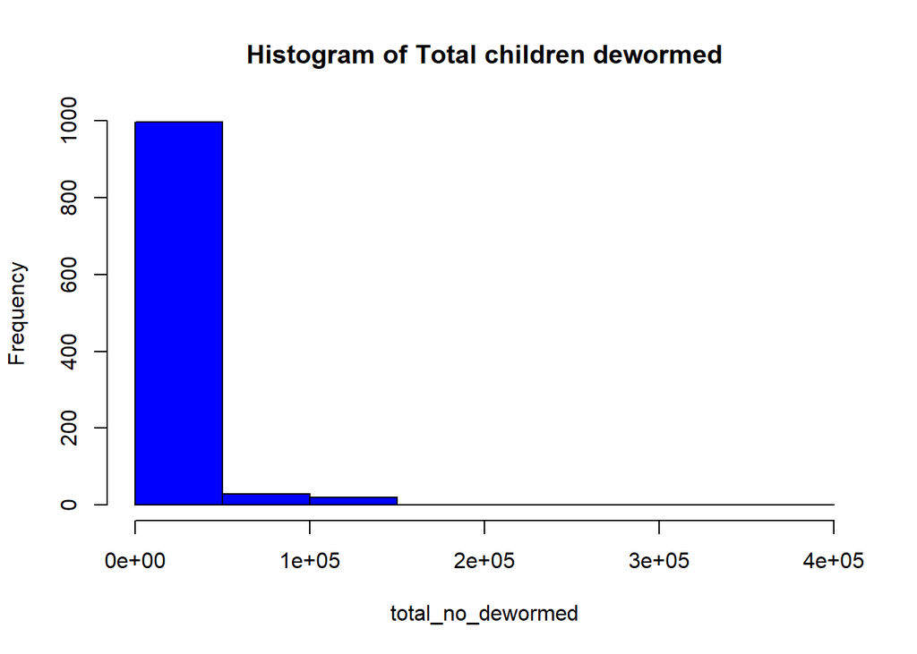

```r
total_no_dewormed <- CEMA.Dataset1$Total.Dewormed
hist(total_no_dewormed, col = "blue", main = "Histogram of Total children dewormed")
```

To check for normality

```r
shapiro.test(total_no_dewormed)
```

```
##
##  Shapiro-Wilk normality test
##
## data:  total_no_dewormed
## W = 0.38276, p-value < 2.2e-16
```

Given the p-value is less than 0.05, the Total.dewormed column is not normally distributed

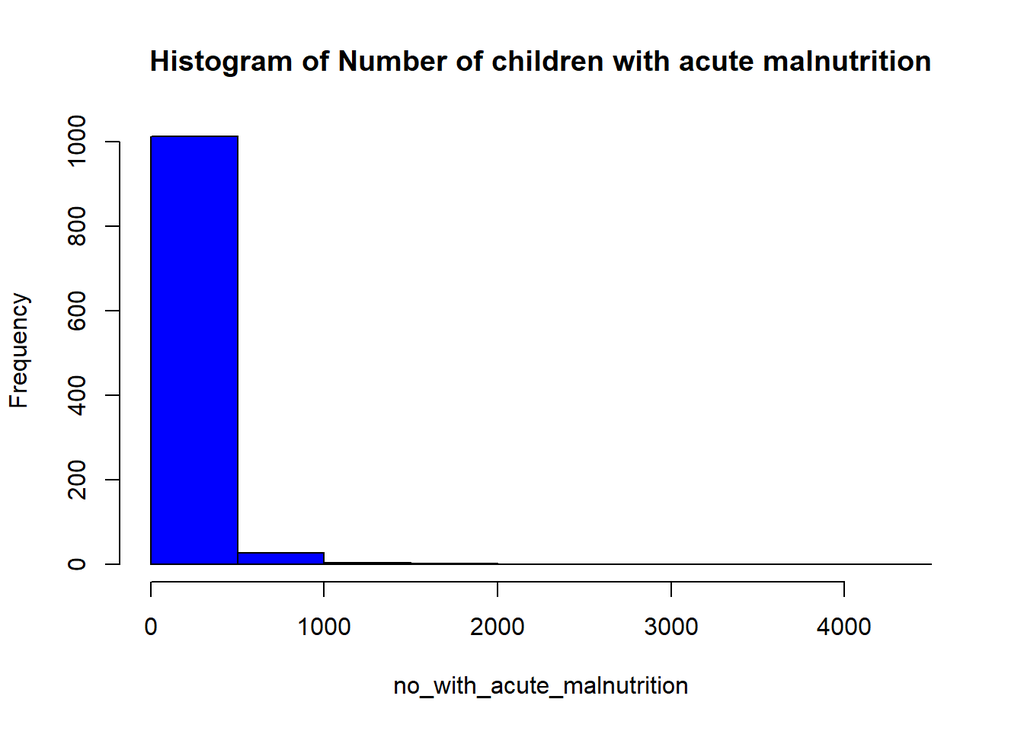

```r
no_with_acute_malnutrition <- CEMA.Dataset1$Acute.Malnutrition
 hist(no_with_acute_malnutrition, col = "blue", main = "Histogram of Number of children with acute malnutrition")
```

```r
shapiro.test(no_with_acute_malnutrition)
```

```
##
##  Shapiro-Wilk normality test
##
## data:  no_with_acute_malnutrition
## W = 0.42454, p-value < 2.2e-16
```

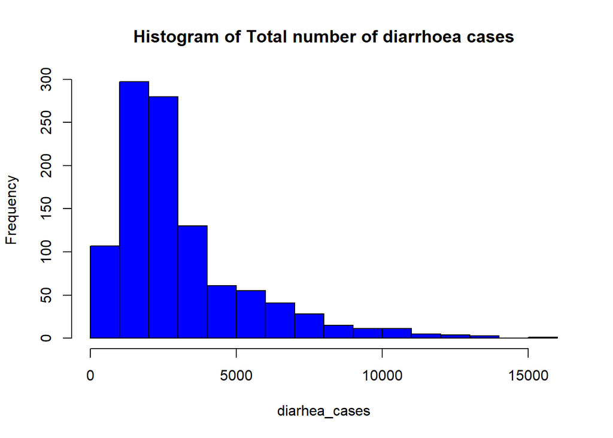

```r
diarhea_cases<- CEMA.Dataset1$diarrhoea.cases
 hist(diarhea_cases, col = "blue", main = "Histogram of Total number of diarrhoea cases")
```

```r
shapiro.test(diarhea_cases)
```

```
##
##  Shapiro-Wilk normality test
##
## data:  diarhea_cases
## W = 0.81543, p-value < 2.2e-16
```

The analyses done shows that the data is not normally distributed and since it is not normally distributed, normalizing it wont make it so. Therefore, the best is to perform the analysis while keeping that in mind.

Research question: Do deworming and illnesses (specifically Diarrhea) impact acute malnutrition, and does acute malnutrition impact stunted growth and underweight children under the age of five in Kenya between January 2021 and June 2023

First is to identify if there is a relationship between the variables

1. Between deworming and acute malnutrition

```r
cor_coefficient <- cor(CEMA.Dataset1$Total.Dewormed, CEMA.Dataset1$Acute.Malnutrition)
print(cor_coefficient)
```

```
## [1] 0.08021801
```

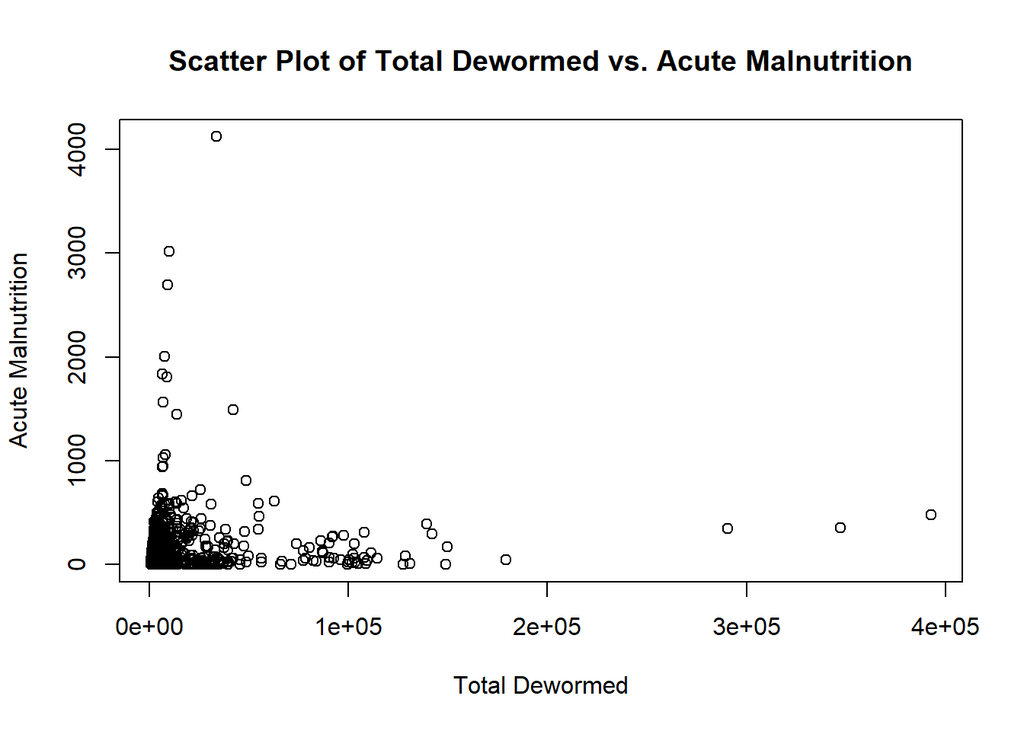

```r
plot(CEMA.Dataset1$Total.Dewormed, CEMA.Dataset1$Acute.Malnutrition,
     xlab = "Total Dewormed",
     ylab = "Acute Malnutrition",
     main = "Scatter Plot of Total Dewormed vs. Acute Malnutrition")
```

2. Between diarrhoea and acute malnutrition

```r
cor_coefficient <- cor(CEMA.Dataset1$diarrhoea.cases, CEMA.Dataset1$Acute.Malnutrition)
print(cor_coefficient)
```

```
## [1] 0.2451361
```

This shows a slight positive correlation between diarrhoea cases and acute malnutrition cases.

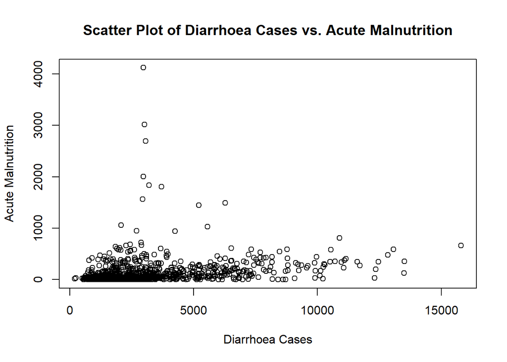

```r
plot(CEMA.Dataset1$diarrhoea.cases, CEMA.Dataset1$Acute.Malnutrition,
     xlab = "Diarrhoea Cases",
     ylab = "Acute Malnutrition",
     main = "Scatter Plot of Diarrhoea Cases vs. Acute Malnutrition")
```

3. Stunted growth in children between 0-6 months and acute malnutrition

```r
cor_coefficient <- cor(CEMA.Dataset1$stunted.0..6.months, CEMA.Dataset1$Acute.Malnutrition)
print(cor_coefficient)
```

```
## [1] 0.07536996
```

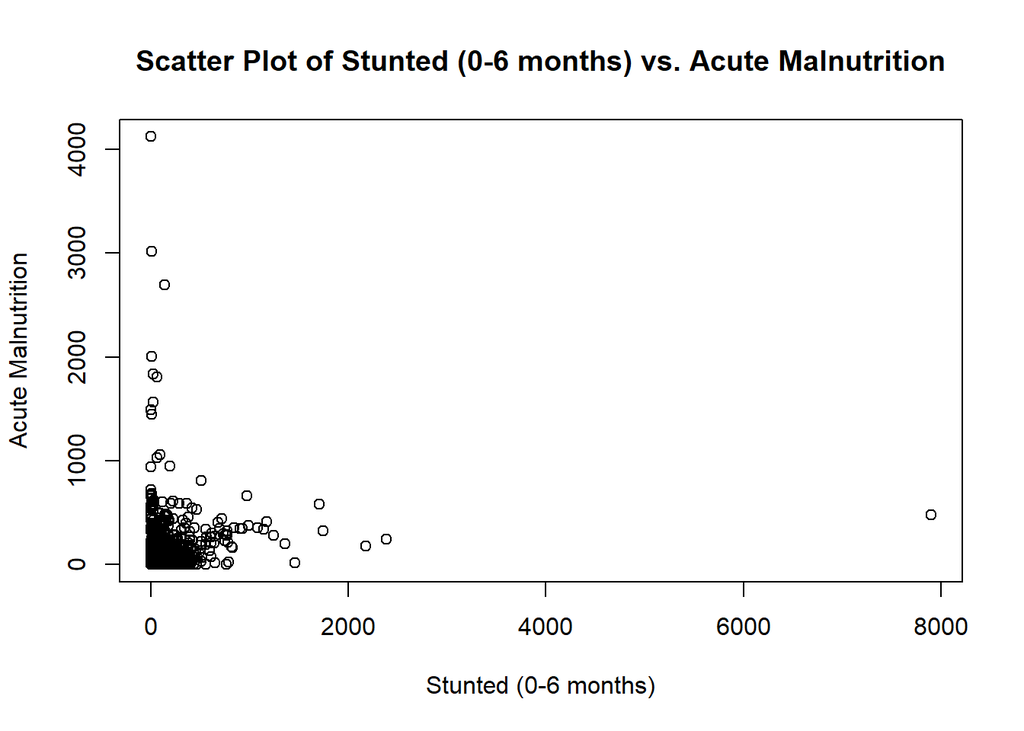

```r
plot(CEMA.Dataset1$stunted.0..6.months, CEMA.Dataset1$Acute.Malnutrition,
     xlab = "Stunted (0-6 months)",
     ylab = "Acute Malnutrition",
     main = "Scatter Plot of Stunted (0-6 months) vs. Acute Malnutrition")
```

4.Stunted growth in children between 6-23 months and acute malnutrition

```r
cor_coefficient <- cor(CEMA.Dataset1$stunted.6.23.months, CEMA.Dataset1$Acute.Malnutrition)
print(cor_coefficient)
```

```
## [1] 0.09848462
```

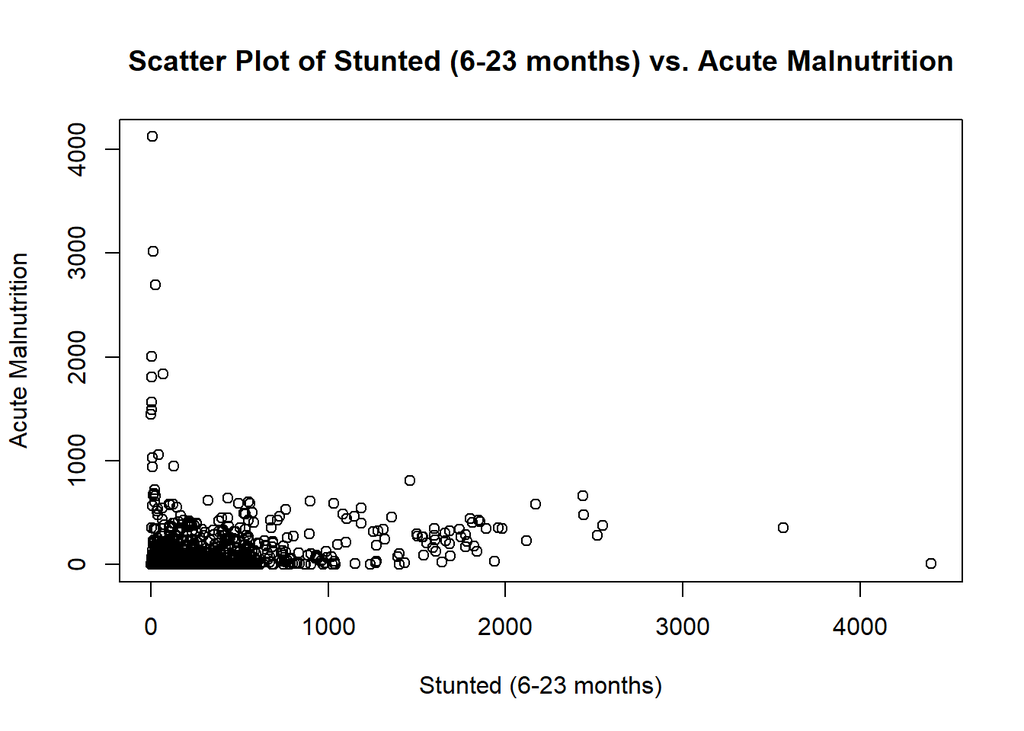

```r
plot(CEMA.Dataset1$stunted.6.23.months, CEMA.Dataset1$Acute.Malnutrition,
     xlab = "Stunted (6-23 months)",
     ylab = "Acute Malnutrition",
     main = "Scatter Plot of Stunted (6-23 months) vs. Acute Malnutrition")
```

5. Stunted growth in children between 24-59 months and acute malnutrition

```r
cor_coefficient <- cor(CEMA.Dataset1$stunted.24.59.months, CEMA.Dataset1$Acute.Malnutrition)
print(cor_coefficient)
```

```
## [1] 0.2375568
```

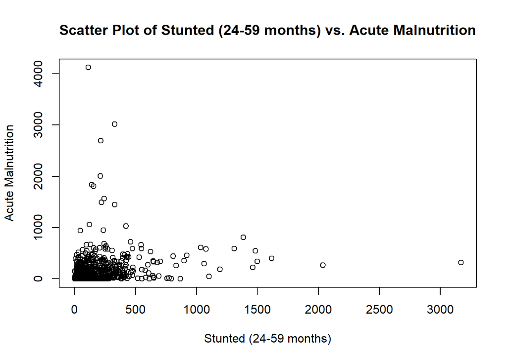

```r
plot(CEMA.Dataset1$stunted.24.59.months, CEMA.Dataset1$Acute.Malnutrition,
     xlab = "Stunted (24-59 months)",
     ylab = "Acute Malnutrition",
     main = "Scatter Plot of Stunted (24-59 months) vs. Acute Malnutrition")
```

6.Acute malnutrition and underweight children between 0-6 months

```r
cor_coefficient <- cor(CEMA.Dataset1$Underweight.0..6.months, CEMA.Dataset1$Acute.Malnutrition)
print(cor_coefficient)
```

```
## [1] 0.1304484
```

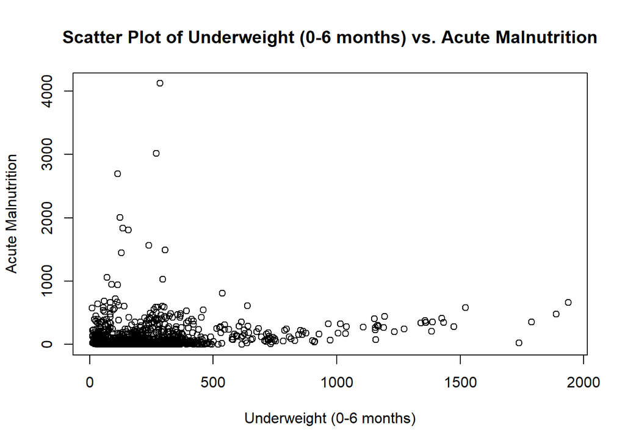

```r
plot(CEMA.Dataset1$Underweight.0..6.months, CEMA.Dataset1$Acute.Malnutrition,
     xlab = "Underweight (0-6 months)",
     ylab = "Acute Malnutrition",
     main = "Scatter Plot of Underweight (0-6 months) vs. Acute Malnutrition")
```

7.Acute malnutrition and underweight children between 6-23 months

```r
cor_coefficient <- cor(CEMA.Dataset1$Underweight.6.23.months, CEMA.Dataset1$Acute.Malnutrition)
print(cor_coefficient)
```

```
## [1] 0.3062168
```

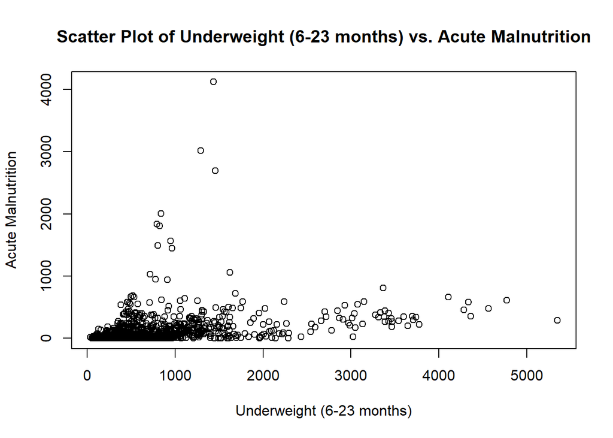

```r
plot(CEMA.Dataset1$Underweight.6.23.months, CEMA.Dataset1$Acute.Malnutrition,
     xlab = "Underweight (6-23 months)",
     ylab = "Acute Malnutrition",
     main = "Scatter Plot of Underweight (6-23 months) vs. Acute Malnutrition")
```

[figure not shown]

```r
plot(CEMA.Dataset1$Underweight.24.59.Months, CEMA.Dataset1$Acute.Malnutrition,
     xlab = "Underweight (24-59 months)",
     ylab = "Acute Malnutrition",
     main = "Scatter Plot of Underweight (24-59 months) vs. Acute Malnutrition")
```

The next step is to find out how significant the remaining variable are to each other. This is done using ANOVA.

1. Total number of children dewormed and Acute malnutrition

```r
ANOVA <- aov(Acute.Malnutrition ~ Total.Dewormed, data = CEMA.Dataset1)
summary(ANOVA)
```

```
##                  Df   Sum Sq Mean Sq F value  Pr(>F)
## Total.Dewormed    1   442617  442617   6.781 0.00934 **
## Residuals      1047 68340908   65273
## ---
## Signif. codes:  0 '***' 0.001 '**' 0.01 '*' 0.05 '.' 0.1 ' ' 1
```

The p-value is 0.00934 which is less that 0.05. This means that there is a statistical significant relationship between total number of children dewormed and acute malnutrition at 0.05 level of significance

2. Stunted children and acute malnutrition

```r
ANOVA <- aov(Acute.Malnutrition ~ Stunted_children, data = CEMA.Dataset1)
summary(ANOVA)
```

```
##                    Df   Sum Sq Mean Sq F value   Pr(>F)
## Stunted_children    1  1609654 1609654   25.09 6.42e-07 ***
## Residuals        1047 67173871   64158
## ---
## Signif. codes:  0 '***' 0.001 '**' 0.01 '*' 0.05 '.' 0.1 ' ' 1
```

The p-value in this case is 6.42e-07 and thus it is very small compared to 0.05. This means that there is a highly significant relationship between stunted children and the residuals at 0.05 level of significance. Thus, acute malnutrition can be a significant explanation/contributor for stunted growth since its strong relation to residuals indicate it is a great explanation to the variability in the outcome.

3. Acute malnutrition and diarrhea cases

```r
ANOVA <- aov(Acute.Malnutrition ~ diarhea_cases, data = CEMA.Dataset1)
summary(ANOVA)
```

```
##                 Df   Sum Sq Mean Sq F value   Pr(>F)
## diarhea_cases    1  4133320 4133320   66.94 8.06e-16 ***
## Residuals     1047 64650206   61748
## ---
## Signif. codes:  0 '***' 0.001 '**' 0.01 '*' 0.05 '.' 0.1 ' ' 1
```

4.acute malnutrition and underweight (0-6 months)

```r
ANOVA <- aov(Acute.Malnutrition ~ Underweight.0..6.months, data = CEMA.Dataset1)
summary(ANOVA)
```

```
##                           Df   Sum Sq Mean Sq F value   Pr(>F)
## Underweight.0..6.months    1  1170474 1170474   18.12 2.25e-05 ***
## Residuals               1047 67613051   64578
## ---
## Signif. codes:  0 '***' 0.001 '**' 0.01 '*' 0.05 '.' 0.1 ' ' 1
```

```r
ANOVA <- aov(Acute.Malnutrition ~ Underweight.6.23.months, data = CEMA.Dataset1)
summary(ANOVA)
```

```
##                           Df   Sum Sq Mean Sq F value Pr(>F)
## Underweight.6.23.months    1  6449742 6449742   108.3 <2e-16 ***
## Residuals               1047 62333783   59536
## ---
## Signif. codes:  0 '***' 0.001 '**' 0.01 '*' 0.05 '.' 0.1 ' ' 1
```

```r
ANOVA <- aov(Acute.Malnutrition ~ Underweight.24.59.Months, data = CEMA.Dataset1)
summary(ANOVA)
```

```
##                           Df   Sum Sq Mean Sq F value Pr(>F)
## Underweight.24.59.Months 542 63800488  117713   11.95 <2e-16 ***
## Residuals                506  4983038    9848
## ---
## Signif. codes:  0 '***' 0.001 '**' 0.01 '*' 0.05 '.' 0.1 ' ' 1
```

For all cases of underweight ANOVAs, the p-values are very small indicating a strong relationship between the variable and the residuals. This means that the variable is a great explanation for the variability in the data and thus is a significant contributor to the outcome and holds high statistical significance.